## Practical Machine Learning Assignement

In this exercise, we are using a Human Activity Recognition (HAR) dataset. HAR has emerged as a key research area in the last years and is gaining increasing attention by the pervasive computing research community, especially for the development of context-aware systems.

The dataset has 5 activity classes: sitting-down, standing-up, standing, walking, and sitting.

We will use this dataset to learn to predict the activity class from all the other variables in the dataset. The exercise will include a training set, a quiz set and a test set.

First, let’s read in the training dataset.

```r
set <- read.csv("./pml-training.csv", na.strings=c("NA","#DIV/0!"))
```

Not all variables that appear in the dataset will be used for predicting. I am going to filter the variables to include all variables except user name, X, timestamps and window variables.

```r
predictors <- names(set)[!names(set) %in% c("X", "user_name", "cvtd_timestamp","raw_timestamp_part_1", "raw_timestamp_part_2",
                                            "new_window","num_window")]
set <- set[, predictors]
```

Now, I am going to remove additional columns where more than 1/2 of observations is missing and reset predictors to exclude dropped variables and the dependent variable.

```r
#Remove columns where more than 1/2 of observations is missing:
set <- Filter(function(x){!all(length(which(is.na(x)))/nrow(set)>0.5)},
              set)
predictors <- names(set)[!names(set) %in% "classe"]
```

```r
#Partition Data
inTrain <- createDataPartition(y=set$classe,p=0.7,list=FALSE)

train <- set[inTrain,]
quiz <- set[-inTrain,]
```

## Model #1: RPART

```r
set.seed(1420)
mod1 <- train(classe~., method="rpart", data=train)
out1 <- predict(mod1, newdata=quiz)
matrix1 <- confusionMatrix(out1, quiz$classe)
print(matrix1)
```

```
## Confusion Matrix and Statistics
##
##           Reference
## Prediction    A    B    C    D    E
##          A 1523  487  483  428  166
##          B   31  374   35  179  144
##          C  116  278  508  357  299
##          D    0    0    0    0    0
##          E    4    0    0    0  473
##
## Overall Statistics
##
##                Accuracy : 0.489
##                  95% CI : (0.4762, 0.5019)
##     No Information Rate : 0.2845
##     P-Value [Acc > NIR] : < 2.2e-16
##
##                   Kappa : 0.3318
##  Mcnemar's Test P-Value : NA
##
## Statistics by Class:
##
##                      Class: A Class: B Class: C Class: D Class: E
## Sensitivity            0.9098  0.32836  0.49513   0.0000  0.43715
## Specificity            0.6286  0.91804  0.78391   1.0000  0.99917
## Pos Pred Value         0.4934  0.49017  0.32606      NaN  0.99161
## Neg Pred Value         0.9460  0.85064  0.88029   0.8362  0.88739
## Prevalence             0.2845  0.19354  0.17434   0.1638  0.18386
## Detection Rate         0.2588  0.06355  0.08632   0.0000  0.08037
## Detection Prevalence   0.5246  0.12965  0.26474   0.0000  0.08105
## Balanced Accuracy      0.7692  0.62320  0.63952   0.5000  0.71816
```

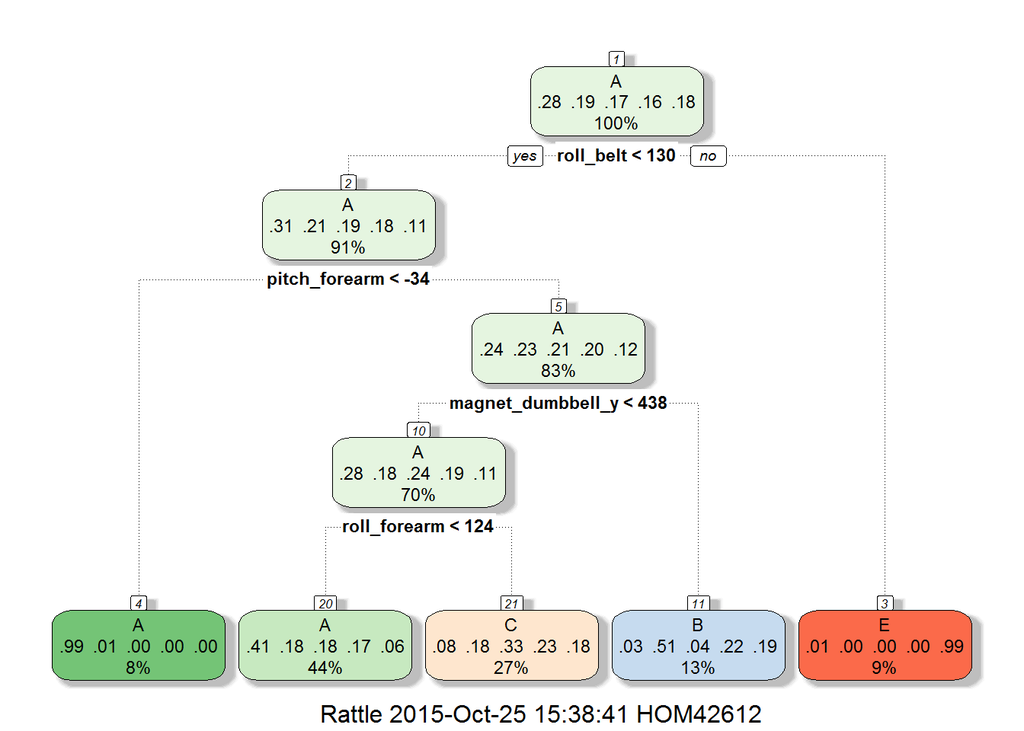

```r
fancyRpartPlot(mod1$finalModel)
```

When running the model on the quiz dataset, we obtain the overall model accuracy of 0.489. While this model is certainly better than a random guess, we will try different tree methods to see if we can improve the predicting power of the algorithm.

## Model #2: Random Forest

```r
set.seed(1420)
registerDoParallel()

mod2 <- foreach(ntree=rep(200,10), .combine=randomForest::combine, .packages = 'randomForest') %dopar% {randomForest(train[,predictors],train$classe,ntree=ntree)}
out2 <- predict(mod2, newdata=quiz[-ncol(quiz)])
matrix2 <- confusionMatrix(out2, quiz$classe)
print(matrix2)
```

```
## Confusion Matrix and Statistics
##
##           Reference
## Prediction    A    B    C    D    E
##          A 1674   11    0    0    0
##          B    0 1127    9    0    0
##          C    0    1 1015    5    1
##          D    0    0    2  959    1
##          E    0    0    0    0 1080
##
## Overall Statistics
##
##                Accuracy : 0.9949
##                  95% CI : (0.9927, 0.9966)
##     No Information Rate : 0.2845
##     P-Value [Acc > NIR] : < 2.2e-16
##
##                   Kappa : 0.9936
##  Mcnemar's Test P-Value : NA
##
## Statistics by Class:
##
##                      Class: A Class: B Class: C Class: D Class: E
## Sensitivity            1.0000   0.9895   0.9893   0.9948   0.9982
## Specificity            0.9974   0.9981   0.9986   0.9994   1.0000
## Pos Pred Value         0.9935   0.9921   0.9932   0.9969   1.0000
## Neg Pred Value         1.0000   0.9975   0.9977   0.9990   0.9996
## Prevalence             0.2845   0.1935   0.1743   0.1638   0.1839
## Detection Rate         0.2845   0.1915   0.1725   0.1630   0.1835
## Detection Prevalence   0.2863   0.1930   0.1737   0.1635   0.1835
## Balanced Accuracy      0.9987   0.9938   0.9939   0.9971   0.9991
```

When running the random forest model, we obtain prediction accuracy in the quiz dataset of 0.9949. This is a very good result.

## Model #3: Boosting

```r
print(matrix3)
```

[output not shown]

```
## Confusion Matrix and Statistics
##
##           Reference
## Prediction    A    B    C    D    E
##          A 1651   38    2    0    4
##          B   15 1073   36    2   19
##          C    3   26  973   36    7
##          D    4    0   12  921   17
##          E    1    2    3    5 1035
##
## Overall Statistics
##
##                Accuracy : 0.9606
##                  95% CI : (0.9553, 0.9654)
##     No Information Rate : 0.2845
##     P-Value [Acc > NIR] : < 2.2e-16
##
##                   Kappa : 0.9501
##  Mcnemar's Test P-Value : 6.008e-08
##
## Statistics by Class:
##
##                      Class: A Class: B Class: C Class: D Class: E
## Sensitivity            0.9863   0.9421   0.9483   0.9554   0.9566
## Specificity            0.9896   0.9848   0.9852   0.9933   0.9977
## Pos Pred Value         0.9740   0.9371   0.9311   0.9654   0.9895
## Neg Pred Value         0.9945   0.9861   0.9890   0.9913   0.9903
## Prevalence             0.2845   0.1935   0.1743   0.1638   0.1839
## Detection Rate         0.2805   0.1823   0.1653   0.1565   0.1759
## Detection Prevalence   0.2880   0.1946   0.1776   0.1621   0.1777
## Balanced Accuracy      0.9879   0.9634   0.9668   0.9743   0.9771
```

When running boosting model, we obtain prediction accuracy in the quiz dataset of 0.961.

Let’s bring in the test data set.

```r
test <- read.csv("./pml-testing.csv", na.strings=c("NA","#DIV/0!"))
```

Creating files for submission:

```r
answers <- as.character(out_test)
pml_write_files = function(x){
  n = length(x)
  path <- "predictionAssignment_files/answers"
  for(i in 1:n){
    filename = paste0("problem_id_",i,".txt")
    write.table(x[i],file=file.path(path, filename),quote=FALSE,row.names=FALSE,col.names=FALSE)
  }
}
pml_write_files(answers)
```